# Chen_Final Project

Emma Chen

11/21/2019

### Overview

```
My project study whether administration of both JAK inhibitors and immune checkpoint blockade therapy (anti-PD1) improves tumor resistance so patients will response to immunotherapy better, improve survival and have more powerful tumor response. My dataset included Flow Cytometry and CyTOF of 1 of 7…
```

### Introduction

```
My project is to investigate whether combined administration of JAK inhibitor and immune checkpoint blockade (ICB)–anti-PD1 immunotherapy is better than with only ICB over time. Currently, ICB, either anti-PD1 or anti-CTLA4, is used to treat cancer patients. ICB functions as taking the brake off imm…

Since this finding, some patients were given only ICB or both ICB and JAK inhibitors to test if JAK inhibitors actually improve tumor resistance problem. Clinical data and blood samples were obtain from 7 patients in our study across 8 different timepoints (one treatment cycle every 3 weeks). Blood …

There are 4 objectives in total.
  -First is to use different R packages to analyze both flow and mass cytometry data; current analysis workflow is to use FlowJo or CyTOF to analyze cytometry data. But as manual gating is time consuming for so many markers and very subjective according to the person doing analysis, we decided to ex…
  -Second is to design and simplify (longitudinal) data analysis workflow for different dataset type, different study goals, different dataset size, variables, etc.
  -Third is so compare Immune Checkpoint Blockage (ICB) only versus both JAK inhibitors and ICB combination, allowing us to confirm main hypothesis whether IFN pathway inhibition improve ICB immunotherapy effects. -Last, to pipeline analyzing multiple patients' data.
  -Last but not least, clinical data can be used to profile patients and determine if clinical data has correlation to patient’s immune profile.
```

### Methods

```
Data analysis workflow for cytometry data have a few steps:
  -concatenate multiple files into one file (which files to concatenate depends on study questions). In my project, I concatenate all 8 timepoints' .fcs files of 1 patient together (will indicate below).
  -input .fcs files into readable format in R, such as matrixs.
  -clean up matrix:define which column has which protein markers, choose protein markers of interest, delete columns would not use for following analysis, such as FSC, SSC gates based on cell size and granularity, or dead cells and dump (cells other than target cell types).
  -reduce dimensionality. Here we evaluate two packages: viSNE and UMAP based on how well they show large-scale information, data-consistency and run time.
  -cluster cells based on common markers they expressed, also known as their fingerprints.
  -use MEM package (Marker Enrichment Modeling, developed by the Irish Lab of Vanderbilt University) to do immune profiling and dig deeper into cluster features

Data analysis workflow for immune profiling have a few steps:
  -from MEM, get cluster information on protein expression
  -PCA analysis and see if cluster express certain markers
  -replicate flowjo analysis on timepoints of choice (c2, c4 and c8, explained later)
```

### Results Part I: tSNE vs UMAP+flowSOM+MEM

### Step 0.1: run libraries needed for analysis

```r
library(FlowSOM)
library(flowCore)
library(Biobase)
```

```r
library(gplots)
library(ggplot2)
library(hexbin)
library(MEM)
library(tidyverse)
library(Rtsne)
library(uwot)
library(viridis)
library(ggExtra)
library(premessa)
library(ggbiplot)
```

### Step 0.2: set and confirm working directory

```r
setwd("C:/Users/Emma/Documents/BMIN503_Final_Project")
getwd()
```

### Step 1: use package Premessa ’s concatenate_fcs_files function to concatenate files. Out put as .fcs

```r
concat <-  dir(pattern="*.fcs")
concatenate_fcs_files(concat, output.file = "C:/Users/Emma/Documents/BMIN503_Final_Project/concatnated.fcs")
```

### Step 2: Cleanup data for analysis:

```
-look at concatenated fcs file first to find out markers names.
-replace with fcs file name of dataset
-Read in concatenated FCS file
```

```r
test <-  dir(pattern="concatnated.fcs")


test.data = read.FCS(test, transformation="linearize", which.lines=NULL,
         alter.names=FALSE, column.pattern=NULL, invert.pattern = FALSE,
         decades=0, ncdf = FALSE, min.limit=NULL,
         truncate_max_range = TRUE, dataset=NULL, emptyValue=TRUE,
         channel_alias = NULL)

colnames(test.data)
```

```
##  [1] "FSC-A"                  "FSC-H"                  "FSC-W"
##  [4] "SSC-A"                  "SSC-H"                  "SSC-W"
##  [7] "FJComp-379_28 UV-A"     "FJComp-450_50 Violet-A" "FJComp-470_15 Violet-A"
## [10] "FJComp-515_20 Blue-A"   "FJComp-515_20 Violet-A" "FJComp-515_30 UV-A"
## [13] "FJComp-586_15 Violet-A" "FJComp-586_15 YG-A"     "FJComp-610_20 Violet-A"
## [16] "FJComp-610_20 YG-A"     "FJComp-660_20 Red-A"    "FJComp-660_20 UV-A"
## [19] "FJComp-660_20 Violet-A" "FJComp-660_40 YG-A"     "FJComp-710_50 Blue-A"
## [22] "FJComp-710_50 Violet-A" "FJComp-710_50 YG-A"     "FJComp-730_45 Red-A"
## [25] "FJComp-740_35 UV-A"     "FJComp-750_30 Violet-A" "FJComp-780_60 Blue-A"
## [28] "FJComp-780_60 Red-A"    "FJComp-780_60 YG-A"     "FJComp-800_30 Violet-A"
## [31] "FJComp-820_60 UV-A"     "FlowSOM_cluster_id"     "FlowSOM_metacluster_id"
## [34] "tSNE1"                  "tSNE2"                  "Time"
```

```r
markernames(test.data)
```

```
##  [1] "CD45RA (v)"             "CXCR5 (v)"              "PD1 (v)"
##  [4] "IgG4 (v)"               "Dump"                   "CD8 (v)"
##  [7] "CD127 (v)"              "Tox (v)"                "Tim3 (v)"
## [10] "Eomes (v)"              "TCF (v)"                "CD38 (v)"
## [13] "CCR7 (v)"               "CTLA4 (v)"              "CD226 (v)"
## [16] "CD39 (v)"               "FoxP3 (v)"              "Ki67 (v)"
## [19] "CD27 (v)"               "CD4 (v)"                "CD73 (v)"
## [22] "TIGIT (v)"              "Tbet (v)"               "CD28 (v)"
## [25] "CD3"                    "FlowSOM_cluster_id"     "FlowSOM_metacluster_id"
## [28] "tSNE1"                  "tSNE2"
```

```
columns need to be renamed: 7:31
columns need to be used for SOM
There are 25 markers for later analysis: "CD45RA, CXCR5, PD1, IgG4, dump, CD8, CD127, Tox, Tim3, Eomes, TCF1, CD38, CCR7, CTLA-4, CD226, CD39, FoxP3, Ki67, CD27, CD4, CD73,TIGIT, T-bet, CD28, CD3"
```

### Step 3.1: convert .fcs to flowFrame and to Matrix, define columns of protein markers of interest as previously discussed.

```r
all.data = exprs(test.data)
scaled.data = all.data[, c(7:31)]
overall_seed = 46

colnames(scaled.data) <- c("CD45RA", "CXCR5", "PD1", "IgG4", "dump", "CD8", "CD127", "Tox", "Tim3", "Eomes", "TCF1", "CD38", "CCR7", "CTLA-4", "CD226", "CD39", "FoxP3", "Ki67", "CD27", "CD4", "CD73", "TIGIT", "T-bet", "CD28", "CD3")
```

### Step 3.2a Run t-SNE on markers of interest, reduce dimension

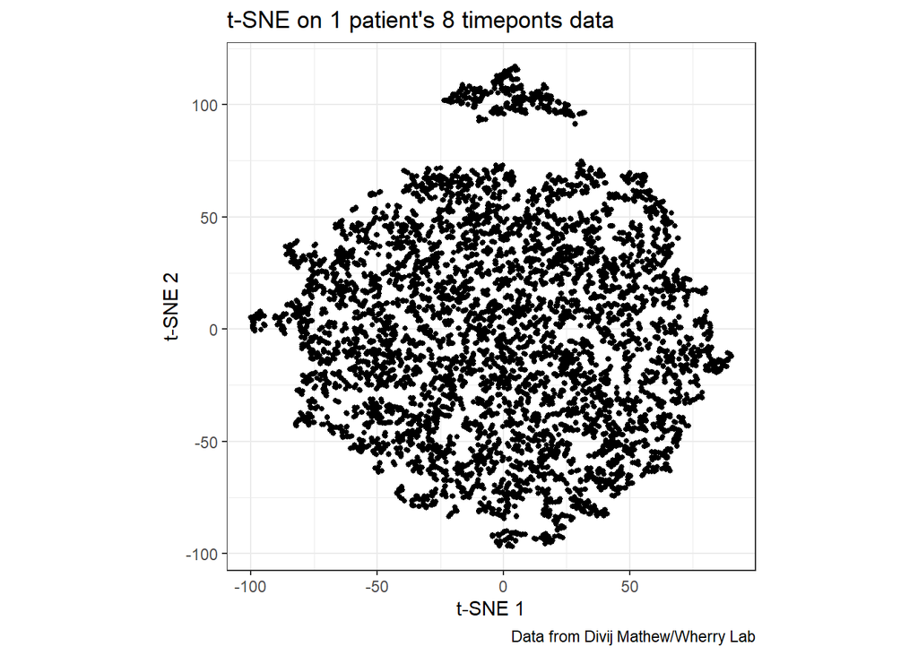

```
note: 1 file with 8000 events, size 1.5Mb, took around 10mins to run
(will compare to UMAP later)
```

```r
set.seed(overall_seed)
mytSNE = Rtsne(
  scaled.data, #column 7:31
  dims = 2,
  initial_dims = 8,
  perplexity = 15,
  check_duplicates = FALSE,
  max_iter = 10000
)
tSNE.data = as.data.frame(mytSNE$Y)
#Matrix containing the new representations for the objects

#open mytSNE to find out what is range
range <- apply(apply(tSNE.data, 2, range), 2, diff)
graphical.ratio.t <- (range[1] / range[2])


# t-SNE flat dot plot and density dot plot (each dot is a patient)
tSNE.plot <- data.frame(x = tSNE.data[, c(1)], y = tSNE.data[, c(2)])

ggplot(tSNE.plot) + coord_fixed(ratio = graphical.ratio.t) +
  geom_point(aes(x = x, y = y), cex = 1) +
  labs(x = "t-SNE 1", y = "t-SNE 2", title = "t-SNE on 1 patient's 8 timeponts data") +
  theme_bw() +
  labs(caption = "Data from Divij Mathew/Wherry Lab")
```

### Step 4: cluster tSNE plot with flowSOM, color code clusters. clusters = 20 based on previous manual gating.

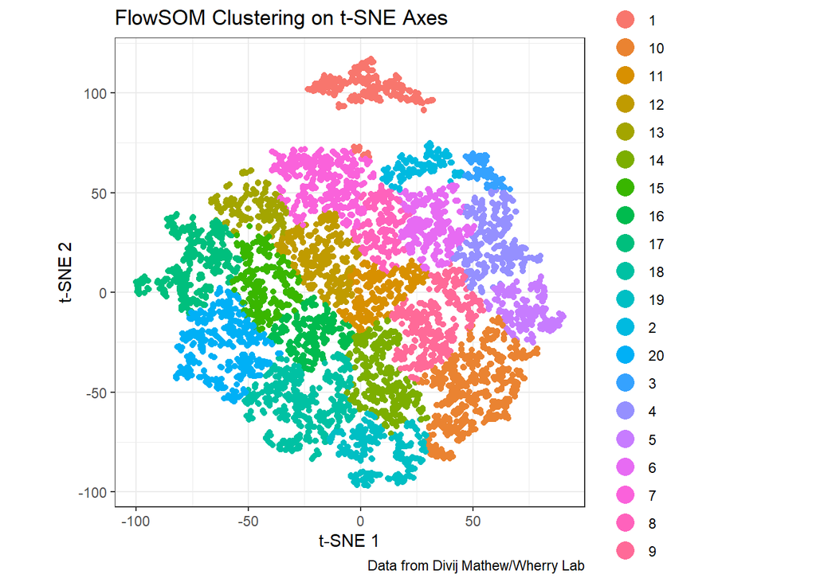

```r
# Run FlowSOM on the t-SNE axes
tSNE.data.mat <- as.matrix(tSNE.data)

# create flowFrame
metadata <-
  data.frame(name = dimnames(tSNE.data.mat)[[2]],
             desc = paste('t-SNE', dimnames(tSNE.data.mat)[[2]]))
metadata$range <- apply(apply(tSNE.data.mat , 2, range), 2, diff)
metadata$minRange <- apply(tSNE.data.mat , 2, min)
metadata$maxRange <- apply(tSNE.data.mat , 2, max)
tSNE.flowframe <- new("flowFrame",
                      exprs = tSNE.data.mat ,
                      parameters = AnnotatedDataFrame(metadata))

# implement the FlowSOM on t-SNE data
fSOM.t <-
  FlowSOM(
    tSNE.flowframe,
    compensate = FALSE,
    transform = FALSE,
    toTransform = c(1:2),
    scale = TRUE,
    colsToUse = c(1:2),
    xdim = 10,
    ydim = 10,
    nClus = 20, #change if needed
    seed = overall_seed
  )
tSNE.FlowSOM.clusters <-
  as.matrix(fSOM.t[[2]][fSOM.t[[1]]$map$mapping[, 1]])

# plot t-SNE with FlowSOM clusters
ggplot(tSNE.plot) + coord_fixed(ratio = graphical.ratio.t) +
  geom_point(aes(x = x, y = y, color = tSNE.FlowSOM.clusters), cex = 1.5) +
  labs(x = "t-SNE 1", y = "t-SNE 2", title = "FlowSOM Clustering on t-SNE Axes",
       color = "FlowSOM Cluster") + theme_bw() +
  guides(colour = guide_legend(override.aes = list(size=5))) +
  labs(caption = "Data from Divij Mathew/Wherry Lab")
```

### step 5: immune profile each cluster with MEM. MEM is good at look at markers that do NOT have a big variation across cells.

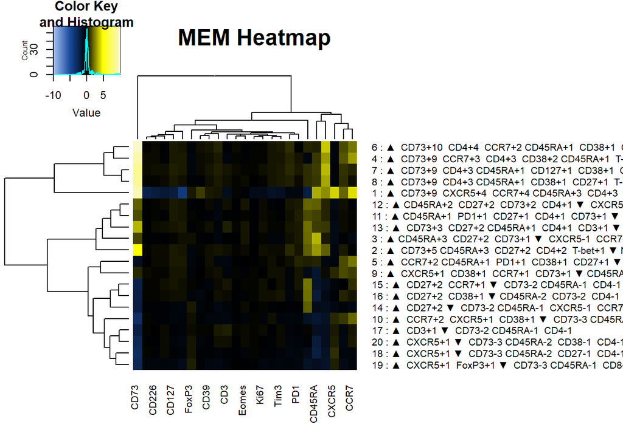

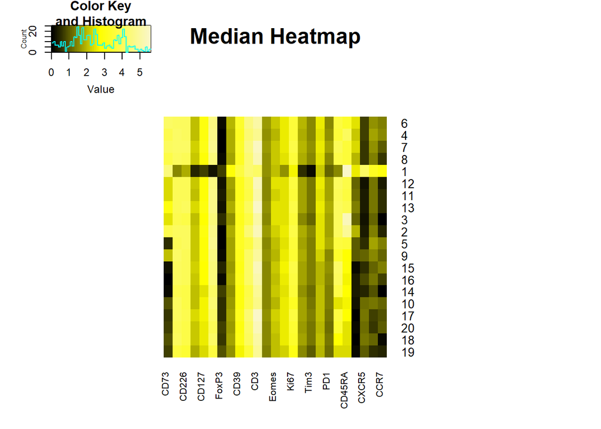

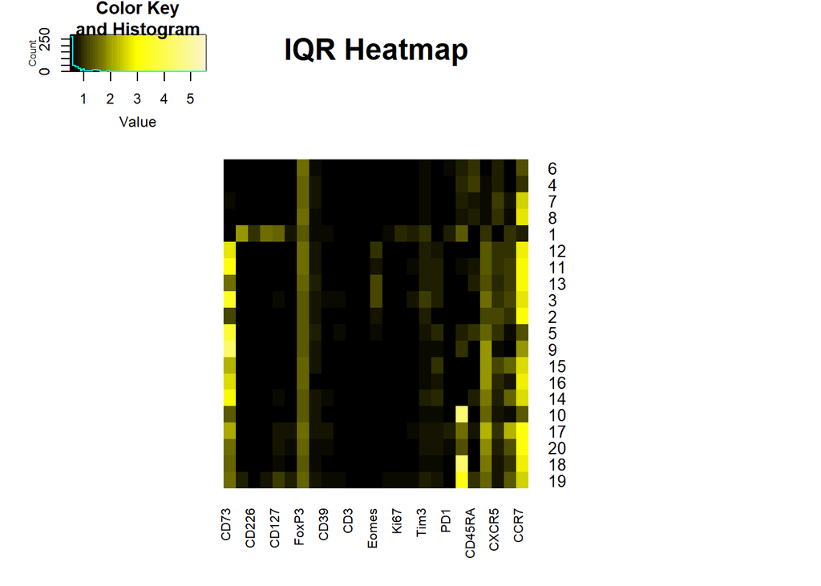

```
## 6 : UP  CD73+10  CD4+4  CCR7+2 CD45RA+1  CD38+1  CD27+1  T-bet+1  CD28+1 • DN None
## 4 : UP  CD73+9  CCR7+3  CD4+3  CD38+2 CD45RA+1  T-bet+1 • DN None
## 7 : UP  CD73+9  CD4+3 CD45RA+1  CD127+1  CD38+1  CCR7+1  CD27+1  T-bet+1  CD28+1 • DN None
## 8 : UP  CD73+9  CD4+3 CD45RA+1  CD38+1  CD27+1  T-bet+1 • DN None
## 1 : UP  CD73+9  CXCR5+4  CCR7+4 CD45RA+3  CD4+3  CD38+2  dump+1 • DN  CD8-4  CD127-2  TCF1-2  CD226-2  CD27-2 TIGIT-2  Tox-1  Tim3-1  CTLA-4-1  Ki67-1  CD3-1
## 12 : UP CD45RA+2  CD27+2  CD73+2  CD4+1 • DN  CXCR5-1
## 11 : UP CD45RA+1  PD1+1  CD27+1  CD4+1  CD73+1 • DN  CXCR5-1
## 13 : UP  CD73+3  CD27+2 CD45RA+1  CD4+1  CD3+1 • DN  CXCR5-1
## 3 : UP CD45RA+3  CD27+2  CD73+1 • DN  CXCR5-1  CCR7-1
## 2 : UP  CD73+5 CD45RA+3  CD27+2  CD4+2  T-bet+1 • DN None
## 5 : UP  CCR7+2 CD45RA+1  PD1+1  CD38+1  CD27+1 • DN  CD73-1
## 9 : UP  CXCR5+1  CD38+1  CCR7+1  CD73+1 • DN CD45RA-2  CD27-1
## 15 : UP  CD27+2  CCR7+1 • DN  CD73-2 CD45RA-1  CD4-1
## 16 : UP  CD27+2  CD38+1 • DN CD45RA-2  CD73-2  CD4-1
## 14 : UP  CD27+2 • DN  CD73-2 CD45RA-1  CXCR5-1  CCR7-1  CD4-1  CD28-1
## 10 : UP  CCR7+2  CXCR5+1  CD38+1 • DN  CD73-3 CD45RA-2  CD27-1  CD4-1
## 17 : UP  CD3+1 • DN  CD73-2 CD45RA-1  CD4-1
## 20 : UP  CXCR5+1 • DN  CD73-3 CD45RA-2  CD38-1  CD4-1
## 18 : UP  CXCR5+1 • DN  CD73-3 CD45RA-2  CD27-1  CD4-1
## 19 : UP  CXCR5+1  FoxP3+1 • DN  CD73-3 CD45RA-1  CD8-1  CD38-1  CD27-1  CD4-1  CD28-1
```

```
Now let's look at how UMAP reduce dimensionality of the SAME dataset for visualization.
```

```r
# Run MEM on the FlowSOM clusters from t-SNE
cluster = as.numeric(as.vector((tSNE.FlowSOM.clusters)))
MEMdata = cbind(scaled.data, cluster)

MEM.values.tf = MEM(
  MEMdata,
  transform = TRUE,
  cofactor = 150,
  choose.markers = FALSE,
  markers = "all",
  choose.ref = FALSE,
  zero.ref = FALSE,
  rename.markers = FALSE,
  new.marker.names = "CD45RA, CXCR5, PD1, IgG4, dump, CD8, CD127, Tox, Tim3, Eomes, TCF1, CD38, CCR7, CTLA-4, CD226, CD39, FoxP3, Ki67, CD27, CD4, CD73,TIGIT, T-bet, CD28, CD3",
  file.is.clust = FALSE,
  add.fileID = FALSE,
  IQR.thresh = NULL,
  output.prescaled.MEM = TRUE
)


# build MEM heatmap and output enrichment scores
build.heatmaps(
  MEM.values.tf,
  cluster.MEM = "both",
  cluster.medians = "none",
  display.thresh = 1,
  newWindow.heatmaps = FALSE,
  output.files = TRUE,
  labels = TRUE,
  only.MEMheatmap = FALSE
)
```

### Step 3.2b: using UMAP to reduce dimensionality

```r
# prepare data for use in UMAP
data <- lapply(lapply(test, read.FCS), exprs) #list apply to read FCS file (read.FCS) and to make it readable (exprs), return list for UMAP. apply takes in 3 arguments: 1 data matrix, 2 row/column operation, function to be applied
ID <- c(1:length(data)) #ID for each file as files are in object (data) now
combined.data = as.data.frame(do.call(rbind, mapply(
  cbind, data, "File ID" = ID, SIMPLIFY = F
)))
combined.data$`File ID` <- as.numeric(combined.data$`File ID`)
chosen.markers = combined.data[, c(7:31)]
transformed.chosen.markers <- chosen.markers %>%
  mutate_all(function(x)
    asinh(x / 15))
overall_seed = 43
```

```r
# Run UMAP on all surface markers
set.seed(overall_seed)
myumap <-
  umap(transformed.chosen.markers,
       ret_model = TRUE,
       n_threads = 1,
       verbose = TRUE)
```

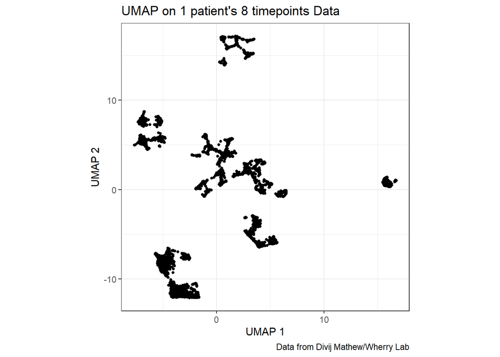

```r
umap.data = as.data.frame(myumap$embedding)

range <- apply(apply(umap.data, 2, range), 2, diff)
graphical.ratio <- (range[1] / range[2])

# UMAP flat dot plot and density dot plot
UMAP.plot <- data.frame(x = umap.data[, 1], y = umap.data[, 2])

ggplot(UMAP.plot) + coord_fixed(ratio = graphical.ratio) +
  geom_point(aes(x = x, y = y), cex = 1) + labs(x = "UMAP 1", y = "UMAP 2",
                                                title = "UMAP on 1 patient's 8 timepoints Data") +
  theme_bw() +
  labs(caption = "Data from Divij Mathew/Wherry Lab")
```

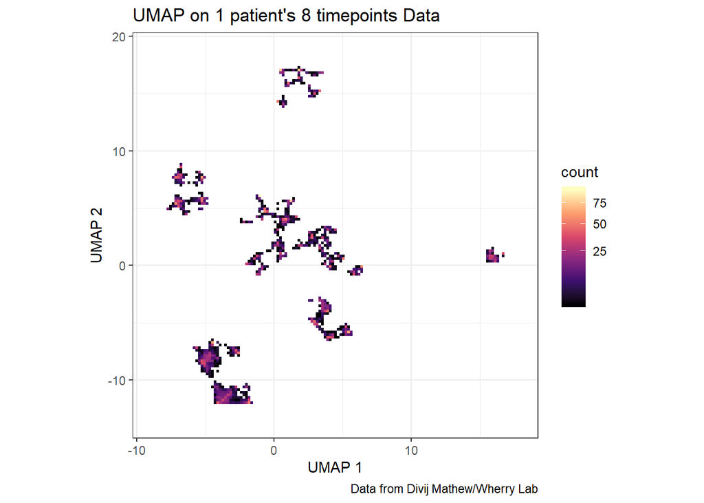

```
Note: same file with 8000 events, size 1.5Mb took 1mins to run a UMAP map.UMAP has timestamp
-One advantage of UMAP over tSNE as a dimension reduction tool is that UMAP has shorter run time.
```

```r
ggplot(UMAP.plot, aes(x = x, y = y)) + coord_fixed(ratio = graphical.ratio)  +
  geom_bin2d(bins = 128) +
  scale_fill_viridis_c(option = "A", trans = "sqrt") +
  scale_x_continuous(expand = c(0.1, 0)) +
  scale_y_continuous(expand = c(0.1, 0)) + labs(x = "UMAP 1", y = "UMAP 2",
                                                title = "UMAP on 1 patient's 8 timepoints Data") +
  theme_bw() +
  labs(caption = "Data from Divij Mathew/Wherry Lab")
```

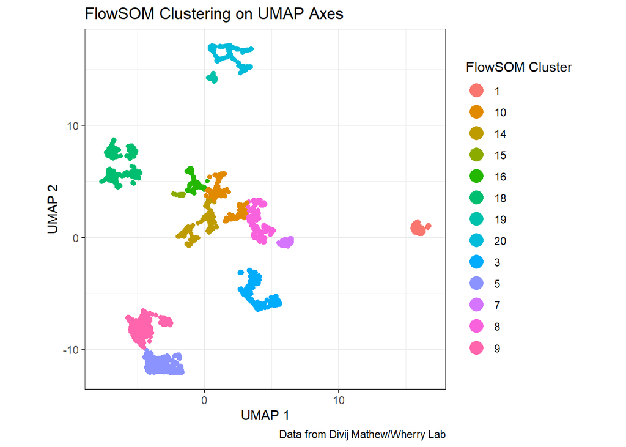

```
Note:
comparing this dimension reduction graph from UMAP, we can see more distinct clusters than tSNE's.
  -Another advantage of UMAP over tSNE is that it can show inter-cluster relation better, which is very important if dataset size increases.
```

```r
# Run FlowSOM on the UMAP axes
umap.matrix <- as.matrix(umap.data)

# create flowFrame
UMAP.metadata <-
  data.frame(name = dimnames(umap.matrix)[[2]],
             desc = paste('UMAP', dimnames(umap.matrix)[[2]]))
UMAP.metadata$range <- apply(apply(umap.matrix, 2, range), 2, diff)
UMAP.metadata$minRange <- apply(umap.matrix, 2, min)
UMAP.metadata$maxRange <- apply(umap.matrix, 2, max)
umap.flowframe <- new("flowFrame",
                      exprs = umap.matrix,
                      parameters = AnnotatedDataFrame(UMAP.metadata))

# implement the FlowSOM on the data
fsom <-
  FlowSOM(
    umap.flowframe,
    compensate = FALSE,
    transform = FALSE,
    toTransform = c(1:2),
    scale = TRUE,
    colsToUse = c(1:2),
    nClus = 20, #change this
    seed = overall_seed
  )
FlowSOM.clusters <-
  as.matrix(fsom[[2]][fsom[[1]]$map$mapping[, 1]])

# plot FlowSOM clusters on UMAP axes
ggplot(UMAP.plot) + coord_fixed(ratio=graphical.ratio) +
  geom_point(aes(x=x, y=y, color=FlowSOM.clusters),cex = 1.5) +
  labs(x = "UMAP 1", y = "UMAP 2",title = "FlowSOM Clustering on UMAP Axes",
       color = "FlowSOM Cluster") + theme_bw() +
  guides(colour = guide_legend(override.aes = list(size=5)))+
  labs(caption = "Data from Divij Mathew/Wherry Lab")
```

### step 5: immune profile each cluster with MEM. MEM is good at look at markers that do NOT have a big variation across cells.

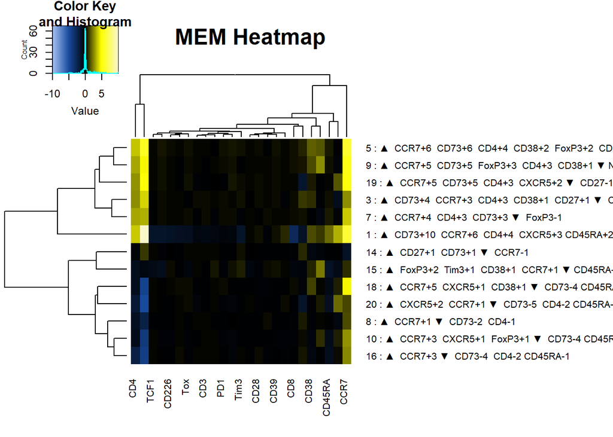

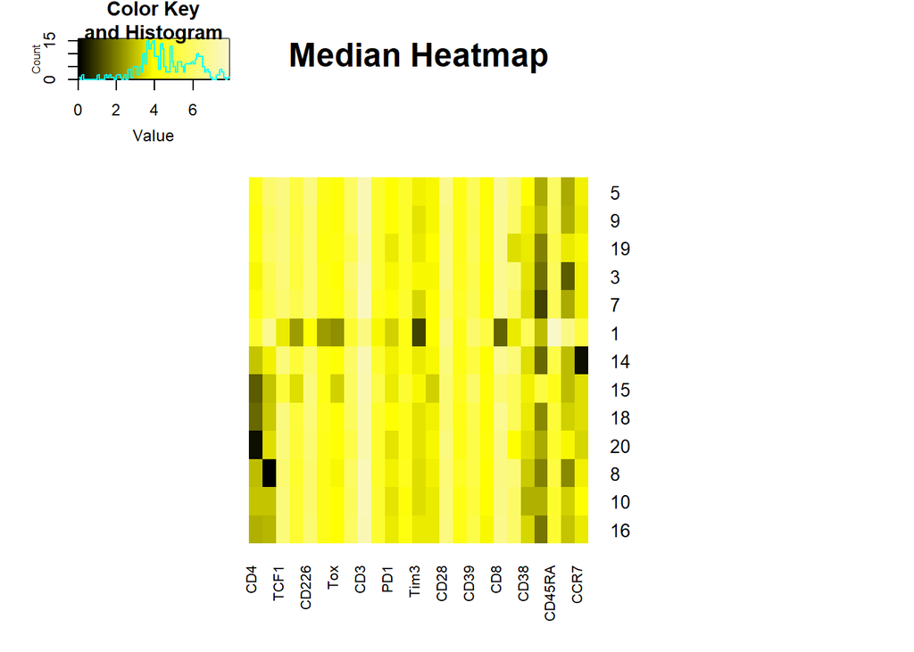

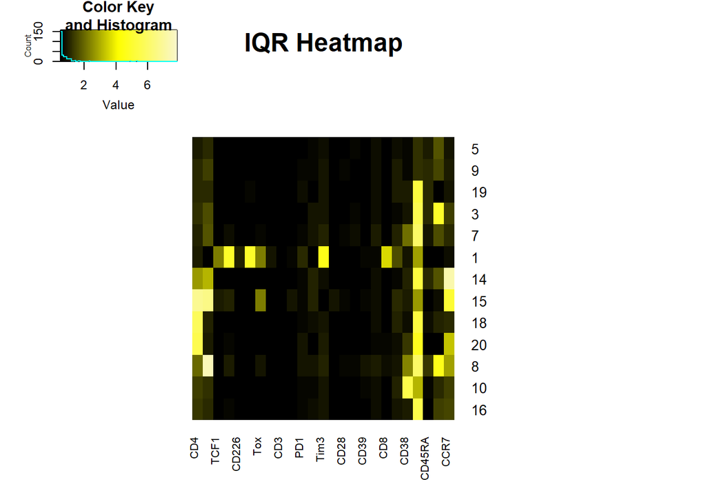

```
## 5 : UP  CCR7+6  CD73+6  CD4+4  CD38+2  FoxP3+2  CD27+1 • DN None
## 9 : UP  CCR7+5  CD73+5  FoxP3+3  CD4+3  CD38+1 • DN None
## 19 : UP  CCR7+5  CD73+5  CD4+3  CXCR5+2 • DN  CD27-1
## 3 : UP  CD73+4  CCR7+3  CD4+3  CD38+1  CD27+1 • DN  CXCR5-1
## 7 : UP  CCR7+4  CD4+3  CD73+3 • DN  FoxP3-1
## 1 : UP  CD73+10  CCR7+6  CD4+4  CXCR5+3 CD45RA+2  dump+1  CD38+1  FoxP3+1 • DN  CD8-3  CD127-1  Tox-1  Tim3-1  TCF1-1  CTLA-4-1  CD226-1  CD27-1 TIGIT-1  CD3-1
## 14 : UP  CD27+1  CD73+1 • DN  CCR7-1
## 15 : UP  FoxP3+2  Tim3+1  CD38+1  CCR7+1 • DN CD45RA-1  CXCR5-1  CD127-1  TCF1-1  CD4-1
## 18 : UP  CCR7+5  CXCR5+1  CD38+1 • DN  CD73-4 CD45RA-1  CD4-1
## 20 : UP  CXCR5+2  CCR7+1 • DN  CD73-5  CD4-2 CD45RA-1  CD27-1
## 8 : UP  CCR7+1 • DN  CD73-2  CD4-1
## 10 : UP  CCR7+3  CXCR5+1  FoxP3+1 • DN  CD73-4 CD45RA-1  CD4-1
## 16 : UP  CCR7+3 • DN  CD73-4  CD4-2 CD45RA-1
```

```
RMSD calculate pair-wise cluster relationship. It determines which markers the population share in common and then calculates the percent maximum RMSD between the two populations. the more red means the two clusters are more similar. With this pair-wise comparison for different population, we can th…

Future directions: compare clusters from different timepoints of the same patients, and between patients. the more red means the clusters have more enrichment MEM scores in common.
```

```r
# Run MEM on the FlowSOM clusters from UMAP
cluster = as.numeric(as.vector((FlowSOM.clusters))) #clusters from UMAP and FlowSOM clustering
MEM.data = cbind(transformed.chosen.markers, cluster)

MEM.values.uf = MEM(
  MEM.data,
  transform = FALSE,
  cofactor = 150,
  choose.markers = FALSE,
  markers = "all",
  choose.ref = FALSE,
  zero.ref = FALSE,
  rename.markers = FALSE,
  new.marker.names = "CD45RA, CXCR5, PD1, IgG4, dump, CD8, CD127, Tox, Tim3, Eomes, TCF1, CD38, CCR7, CTLA-4, CD226, CD39, FoxP3, Ki67, CD27, CD4, CD73,TIGIT, T-bet, CD28, CD3",
  file.is.clust = FALSE,
  add.fileID = FALSE,
  IQR.thresh = NULL,
  output.prescaled.MEM = TRUE
)

# build MEM heatmap and output enrichment scores
build.heatmaps(
  MEM.values.uf,
  cluster.MEM = "both",
  cluster.medians = "none",
  display.thresh = 1,
  newWindow.heatmaps = FALSE,
  output.files = TRUE,
  labels = TRUE,
  only.MEMheatmap = FALSE
)
```

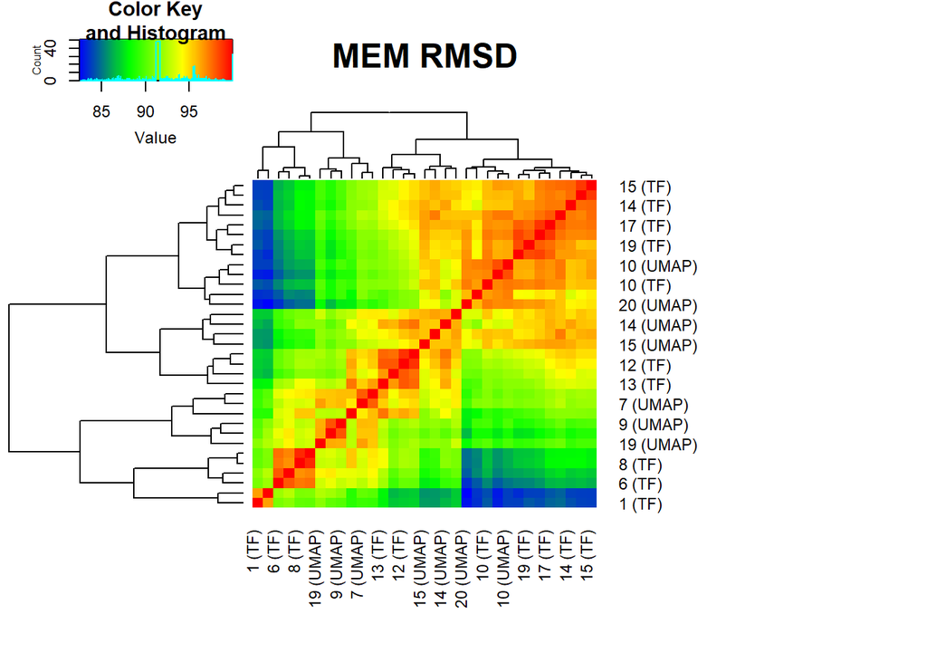

[output not shown]

```r
# RMSD to compare labels from all populations, cluster from TF vs clusters
tf.MEM.scores = as.data.frame(MEM.values.tf[[5]])
rownames(tf.MEM.scores) = paste0(rownames(tf.MEM.scores), ' (TF)')
uf.MEM.scores = as.data.frame(MEM.values.uf[[5]])
rownames(uf.MEM.scores) = paste0(rownames(uf.MEM.scores), ' (UMAP)')
all.MEM.values = as.matrix(rbind(uf.MEM.scores, tf.MEM.scores))

RMSD_vals <-
  MEM_RMSD(
    all.MEM.values,
    format = NULL,
    newWindow.heatmaps = FALSE,
    output.matrix = FALSE
  )
```

### Results Part II: cluster profiles with PCA

```
Cleaning data. Import from txt generate from MEM in the output files' folder. Add a column containing clusterIDs (1-20) for our reference and analysis.

first we can look at tSNE+flowSOM+MEM clusters
```

```r
t <- read.table(file = "C:/Users/Emma/Documents/BMIN503_Final_Project/output files/2019-12-13_161409 Pre-scaled MEM matrix.txt", #Name of file
                header = TRUE, #Does the file have a header (names of columns)?
                sep = "\t", #Character that separates  column entries (tab, space, comma)
                skip = 0, #Number of lines to skip from beginning
                as.is = TRUE, #Should character variables be left alone
                na.strings = NA, #The encoding of missing values. Blanks are assumed missing too.
                comment.char = "#", #Lines of file beginning with this character are ignored. (# default)
                quote = "", #Character used to quote values. "" is no quotes.
                nrows = -1 #The number of rows to read in. Negative/invalid values are ignored
)

cluster <- unlist(rownames(t))
t <- t %>%
  mutate(clusterID = cluster)
```

```r
tMEM.pca <- prcomp(t[, 1:25], scale = TRUE)
summary(tMEM.pca)
```

```
## Importance of components:
##                           PC1    PC2    PC3     PC4     PC5    PC6     PC7
## Standard deviation     3.4049 2.6596 1.6718 1.21357 0.87186 0.6041 0.44816
## Proportion of Variance 0.4637 0.2829 0.1118 0.05891 0.03041 0.0146 0.00803
## Cumulative Proportion  0.4637 0.7467 0.8585 0.91739 0.94779 0.9624 0.97042
##                            PC8     PC9    PC10    PC11    PC12    PC13    PC14
## Standard deviation     0.41889 0.39081 0.33832 0.31526 0.26664 0.22233 0.18108
## Proportion of Variance 0.00702 0.00611 0.00458 0.00398 0.00284 0.00198 0.00131
## Cumulative Proportion  0.97744 0.98355 0.98813 0.99210 0.99495 0.99692 0.99824
##                           PC15    PC16    PC17    PC18    PC19      PC20
## Standard deviation     0.14779 0.10837 0.06761 0.06029 0.04823 1.683e-16
## Proportion of Variance 0.00087 0.00047 0.00018 0.00015 0.00009 0.000e+00
## Cumulative Proportion  0.99911 0.99958 0.99976 0.99991 1.00000 1.000e+00
```

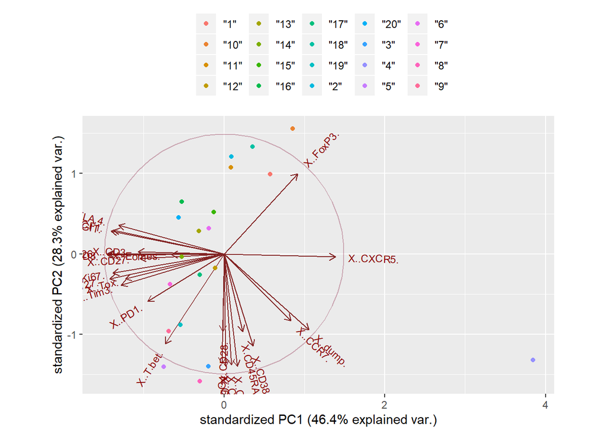

```r
ggbiplot(tMEM.pca, groups = t$clusterID, circle = TRUE) +
  scale_color_discrete(name = '') +
  theme(legend.direction = 'horizontal', legend.position = 'top')
```

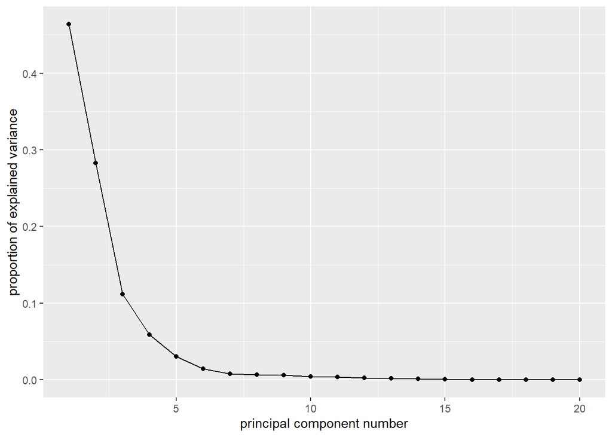

```
a few clusters seem to express hight FoxP3
```

```r
ggscreeplot(tMEM.pca)
```

### Next look at UMAP+flowSOM+MEM clusters.

```r
u <- read.table(file = "C:/Users/Emma/Documents/BMIN503_Final_Project/output files/2019-12-13_161441 Pre-scaled MEM matrix.txt", #Name of file
                header = TRUE, #Does the file have a header (names of columns)?
                sep = "\t", #Character that separates  column entries (tab, space, comma)
                skip = 0, #Number of lines to skip from beginning
                as.is = TRUE, #Should character variables be left alone
                na.strings = NA, #The encoding of missing values. Blanks are assumed missing too.
                comment.char = "#", #Lines of file beginning with this character are ignored. (# default)
                quote = "", #Character used to quote values. "" is no quotes.
                nrows = -1 #The number of rows to read in. Negative/invalid values are ignored
)

cluster2 <- unlist(rownames(u))
u <- u %>%
  mutate(clusterID = cluster2)
```

```r
uMEM.pca <- prcomp(u[, 1:25], scale = TRUE)
summary(uMEM.pca)
```

```
## Importance of components:
##                           PC1    PC2    PC3    PC4     PC5     PC6     PC7
## Standard deviation     3.4812 2.3171 1.7062 1.3276 1.09214 0.78691 0.66049
## Proportion of Variance 0.4848 0.2147 0.1164 0.0705 0.04771 0.02477 0.01745
## Cumulative Proportion  0.4848 0.6995 0.8159 0.8864 0.93416 0.95893 0.97638
##                            PC8     PC9    PC10   PC11    PC12      PC13
## Standard deviation     0.55362 0.32740 0.29673 0.2499 0.16214 1.541e-16
## Proportion of Variance 0.01226 0.00429 0.00352 0.0025 0.00105 0.000e+00
## Cumulative Proportion  0.98864 0.99293 0.99645 0.9990 1.00000 1.000e+00
```

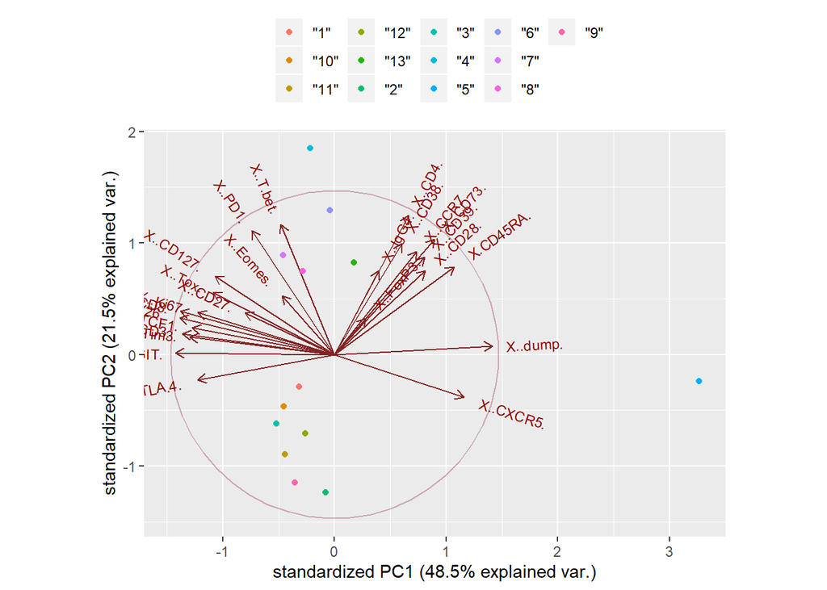

```r
ggbiplot(uMEM.pca, groups = u$clusterID, circle = TRUE) +
  scale_color_discrete(name = '') +
  theme(legend.direction = 'horizontal', legend.position = 'top')
```

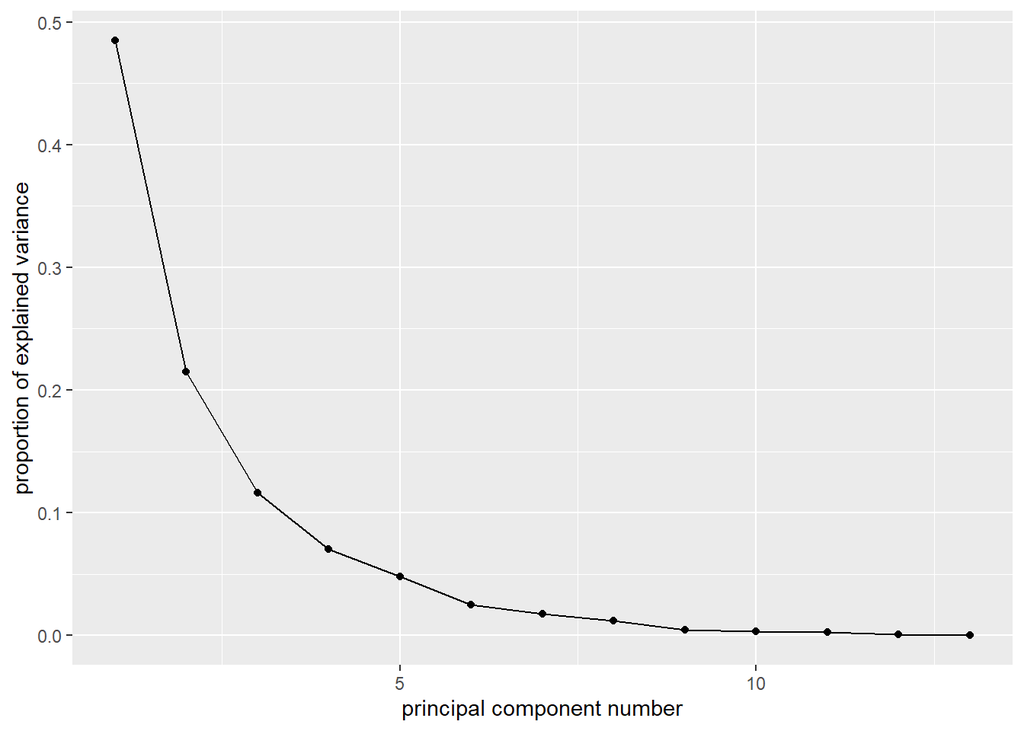

```
Notes: comparing PCA of UMAP and tSNE clusters, cluster's immune profiles and distribution is quite different. Here not many clusters express FoxP3 high.

(cluster number of cells sharing similar immune profil might be different because they are from two different algorithm)
```

```r
ggscreeplot(uMEM.pca)
```

### Results Part III: Immune Profiling at look at two markers’ expression (recrete FlowJO analysis)

[output not shown]

C2: only anti-PD1 C4: both JAK inhibitor and anti-PD1 c8: only anti-PD1

### Step 1: import fcs data from different time points

```r
#c2
c2 <-  dir(pattern="export_export3_Exhastion_2A_029.fcs")

c2 = read.FCS(c2, transformation="linearize", which.lines=NULL,
         alter.names=FALSE, column.pattern=NULL, invert.pattern = FALSE,
         decades=0, ncdf = FALSE, min.limit=NULL,
         truncate_max_range = TRUE, dataset=NULL, emptyValue=TRUE,
         channel_alias = NULL)

c2 = exprs(c2)
c2 = c2[, c(7:31)]
colnames(c2) <- c("CD45RA", "CXCR5", "PD1", "IgG4", "dump", "CD8", "CD127", "Tox", "Tim3", "Eomes", "TCF1", "CD38", "CCR7", "CTLA-4", "CD226", "CD39", "FoxP3", "Ki67", "CD27", "CD4", "CD73", "TIGIT", "T-bet", "CD28", "CD3")

#c4
c4 <-  dir(pattern="export_export3_Exhastion_4A_031.fcs")

c4 = read.FCS(c4, transformation="linearize", which.lines=NULL,
         alter.names=FALSE, column.pattern=NULL, invert.pattern = FALSE,
         decades=0, ncdf = FALSE, min.limit=NULL,
         truncate_max_range = TRUE, dataset=NULL, emptyValue=TRUE,
         channel_alias = NULL)

c4 = exprs(c4)
c4 = c4[, c(7:31)]
colnames(c4) <- c("CD45RA", "CXCR5", "PD1", "IgG4", "dump", "CD8", "CD127", "Tox", "Tim3", "Eomes", "TCF1", "CD38", "CCR7", "CTLA-4", "CD226", "CD39", "FoxP3", "Ki67", "CD27", "CD4", "CD73", "TIGIT", "T-bet", "CD28", "CD3")


#c8
c8 <-  dir(pattern="export_export3_Exhastion_8A_035.fcs")

c8 = read.FCS(c8, transformation="linearize", which.lines=NULL,
         alter.names=FALSE, column.pattern=NULL, invert.pattern = FALSE,
         decades=0, ncdf = FALSE, min.limit=NULL,
         truncate_max_range = TRUE, dataset=NULL, emptyValue=TRUE,
         channel_alias = NULL)

c8 = exprs(c8)
c8 = c8[, c(7:31)]
colnames(c8) <- c("CD45RA", "CXCR5", "PD1", "IgG4", "dump", "CD8", "CD127", "Tox", "Tim3", "Eomes", "TCF1", "CD38", "CCR7", "CTLA-4", "CD226", "CD39", "FoxP3", "Ki67", "CD27", "CD4", "CD73", "TIGIT", "T-bet", "CD28", "CD3")

c2 <- as.data.frame(c2)
c4 <- as.data.frame(c4)
c8 <- as.data.frame(c8)
```

### Step 2: CD4 vs CD8

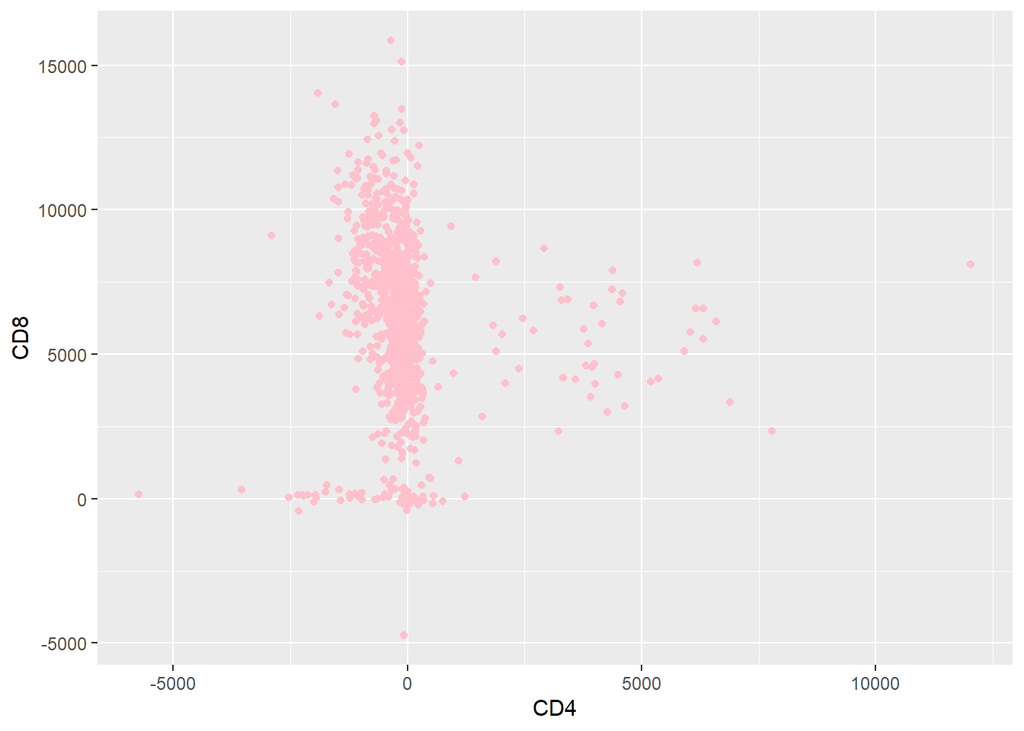

```r
#c2
ggplot(data = c2, aes(x = CD4, y = CD8 )) +
    geom_point(color = "pink")
```

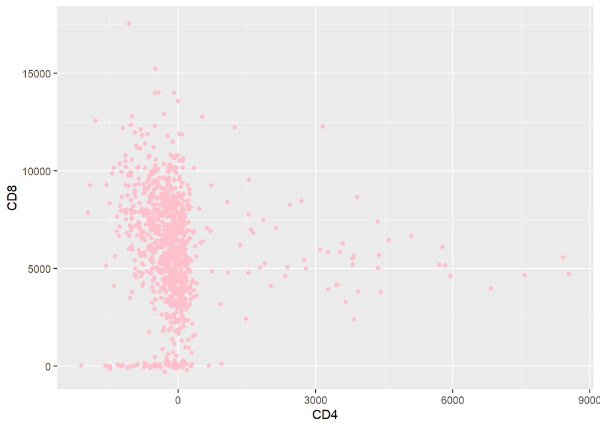

```r
#c4
ggplot(data = c4, aes(x = CD4, y = CD8 )) +
    geom_point(color = "pink")
```

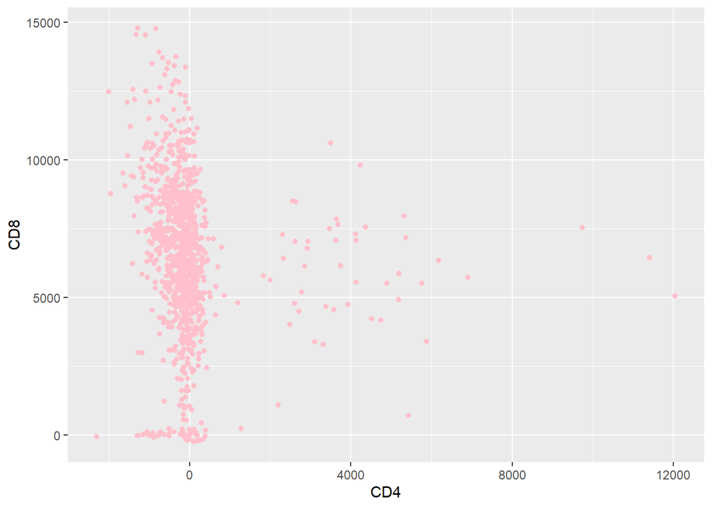

```
Note: theres bigger CD8 population than CD4.
```

```r
#c8
ggplot(data = c8, aes(x = CD4, y = CD8 )) +
    geom_point(color = "pink")
```

### Step 3: inhibitory protein TIGIT vs activator protein CD226

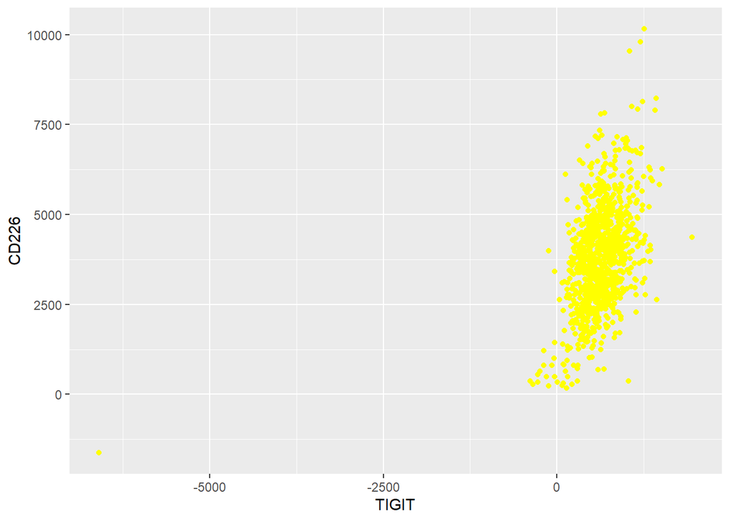

```r
#c2:
ggplot(data = c2, aes(x = TIGIT, y = CD226 )) +
    geom_point(color = "yellow")
```

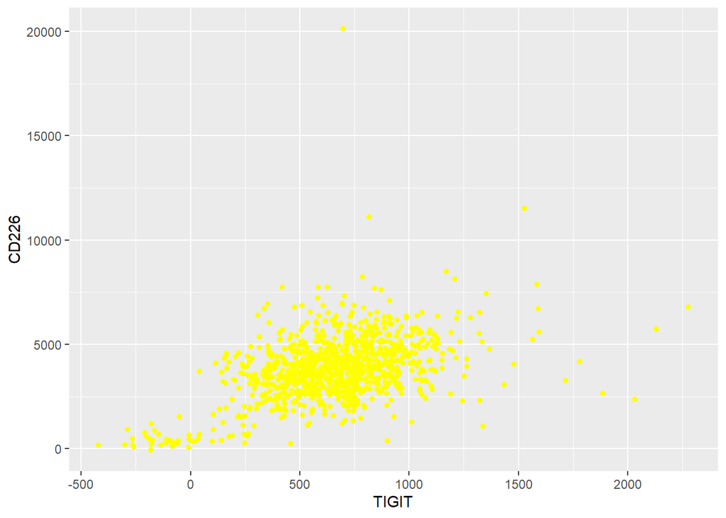

```r
#c4:
ggplot(data = c4, aes(x = TIGIT, y = CD226 )) +
    geom_point(color = "yellow")
```

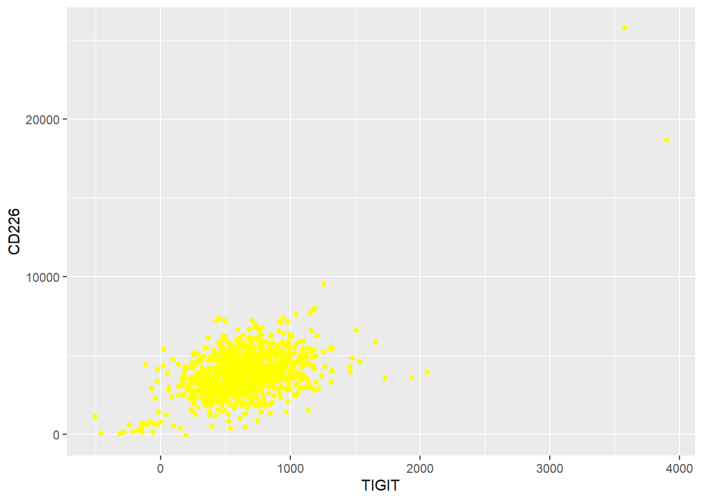

```
Note: axis limit is different for these 3 graphs. C2 might not have good TIGIT staining.It's hard to see if exhaustion marker TIGIT decreases overtime
```

```r
#c8:
ggplot(data = c8, aes(x = TIGIT, y = CD226 )) +
    geom_point(color = "yellow")
```

### Step 4: exhaustion marker Tox vs Wnt-signlaing TCF1

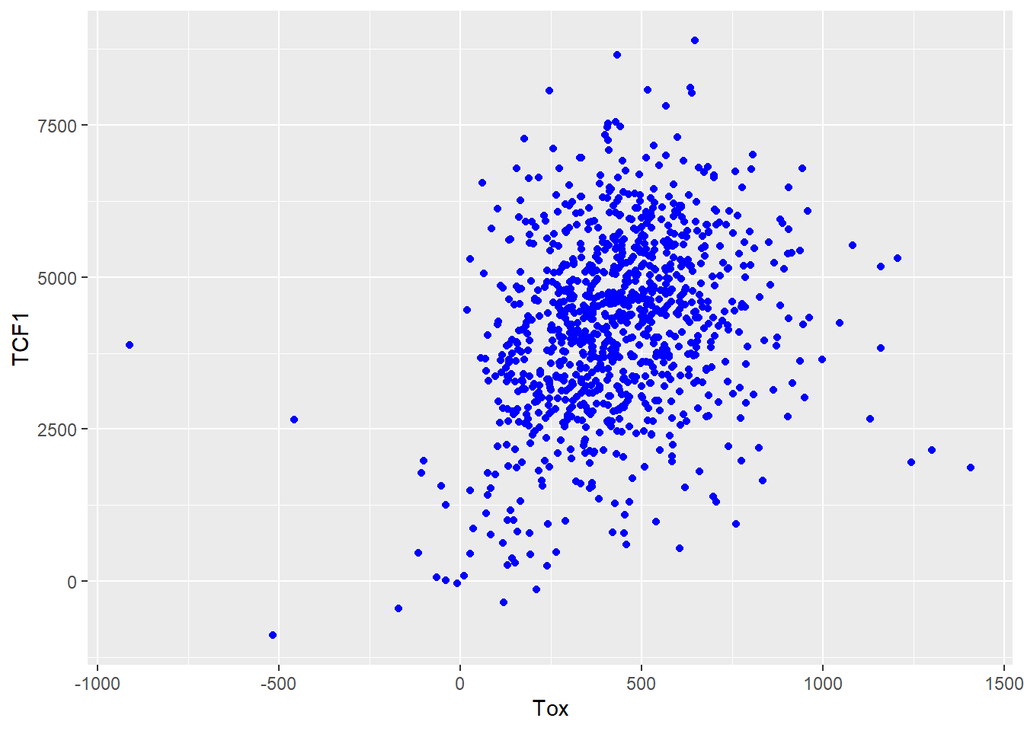

```r
#c2
ggplot(data = c2, aes(x = Tox, y = TCF1 )) +
    geom_point(color = "blue")
```

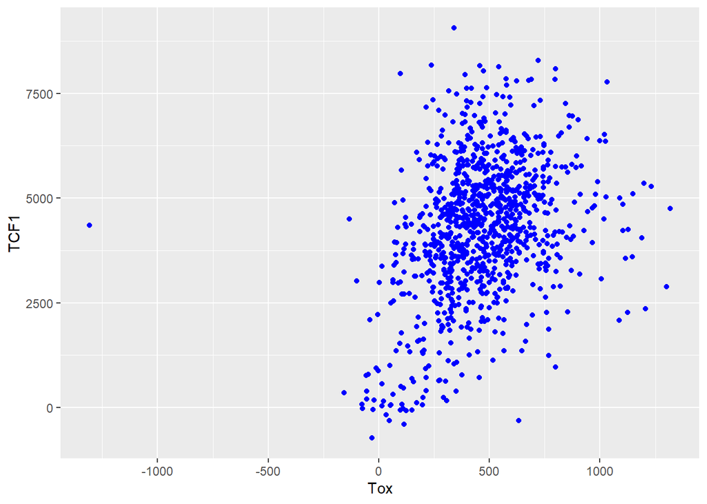

```r
#c4
ggplot(data = c4, aes(x = Tox, y = TCF1 )) +
    geom_point(color = "blue")
```

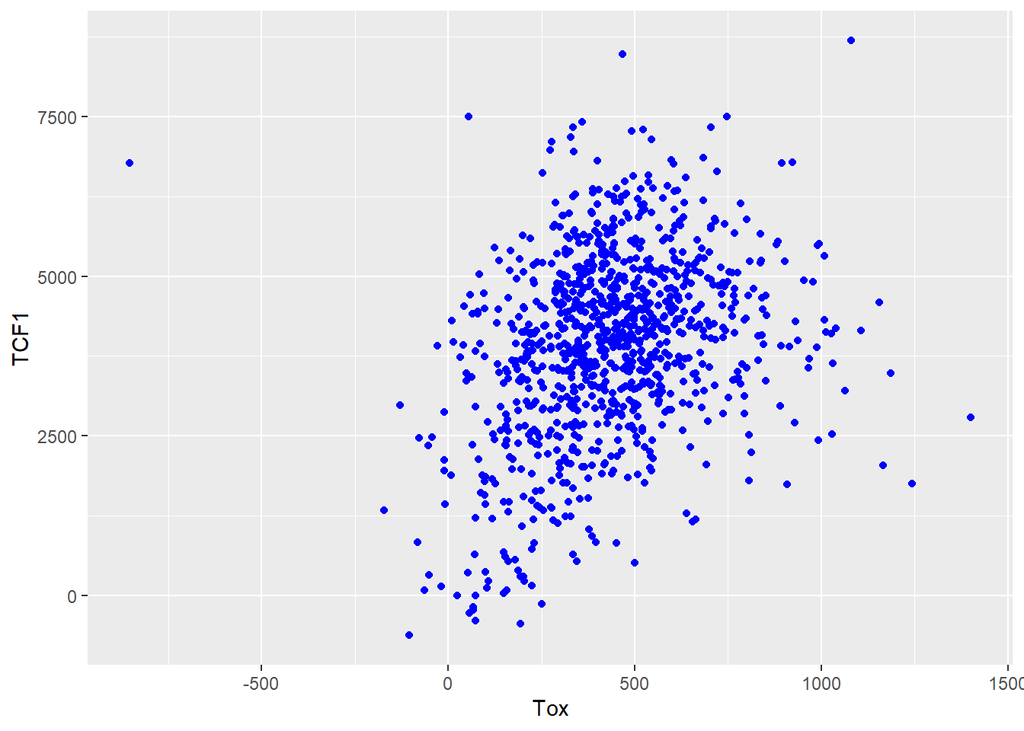

```
Note: not much change among timepoints for these two markers.
```

```r
#c8
ggplot(data = c8, aes(x = Tox, y = TCF1 )) +
    geom_point(color = "blue")
```

### Step 5: PD1 vs PD1 marker IgG4 in this experiment. Since patient takes antiPD1 therapy, drug might already bind PD-1 receptor. for us to quantify PD1, we use IgG4 to bind the Fc region of monocolonal antibody drug anti-PD1.

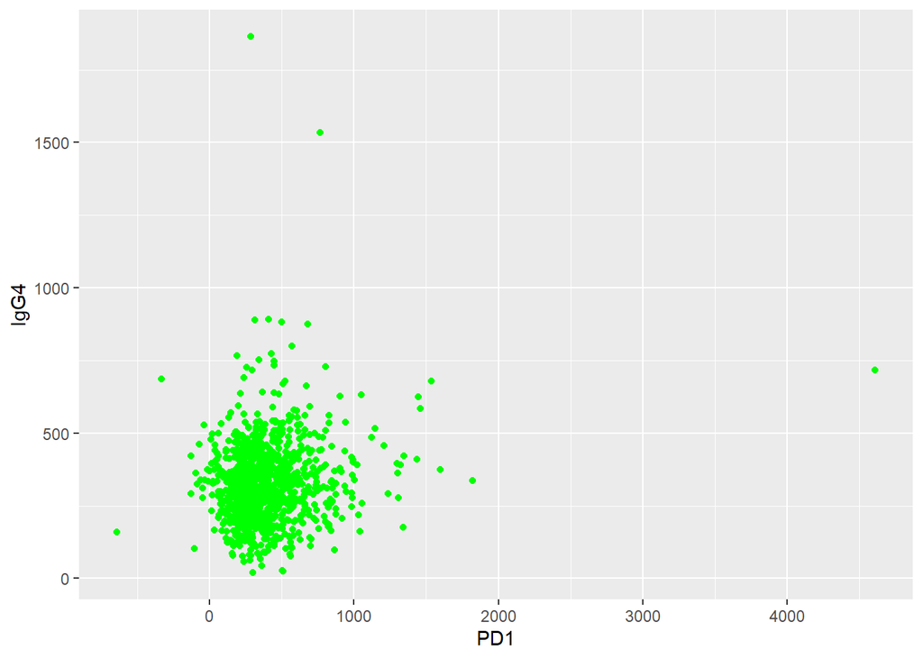

```r
#c2
ggplot(data = c2, aes(x = PD1, y = IgG4 )) +
    geom_point(color = "green")
```

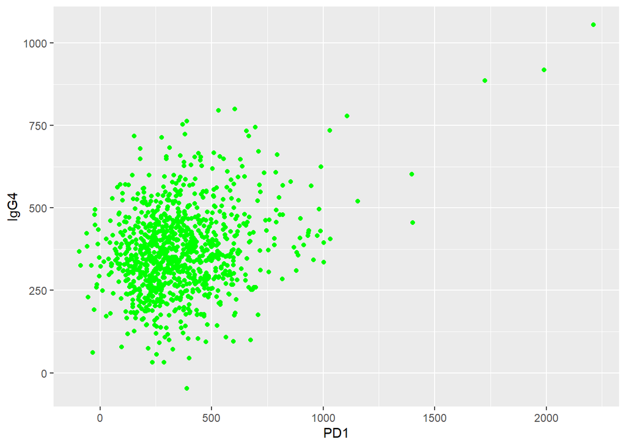

```r
#4
ggplot(data = c4, aes(x = PD1, y = IgG4 )) +
    geom_point(color = "green")
```

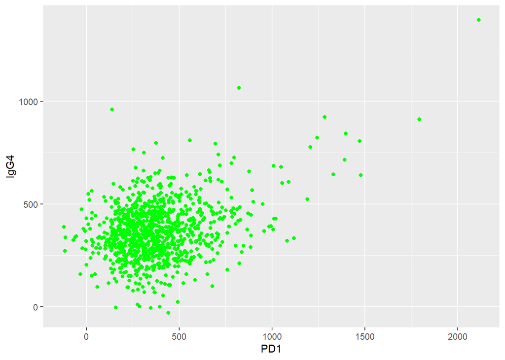

```
Note: not much change either :(
```

```r
#c8
ggplot(data = c8, aes(x = PD1, y = IgG4 )) +
    geom_point(color = "green")
```

### Discussion:

### tSNE and UMAP to reduce dataset dimension.

```
There are a few limitations of viSNE:
  1-It could not meaningfully represent very large datasets
      it might lose large-scale info, the inter-cluster relationship,
      this could be a problem when we are analyzing genomic data,
      it does not scale really well for rapidly increasing sample sizes in scRNA seq.
  2-and it takes a longer time to compute (my project's viSNE took more than 15mins to run on 8000 events, UMAP took less than 1min, with start and end timestamp)

On the other hand, UMAP has a faster runtime, data consistency and more meaningful organization of cell clusters
That does not mean viSNE is inferior to UMAP. To use which data visualization methods, PCA, viSNE, UMAP or others, depends on what questions we are trying to answer, the dataset size, variability.

As for designing cytometry workflow, R is capable to do concatenation, gating based on markers threshold, reduce dimensionality without GUI, cluster without GUI, and do immume profiling even protein marker does not vary obviously in manual gating.

But initial gating should better be done for cells of interest.
```

### Immune profiling:

[output not shown]

### Future directions:

```
1-Immune profile changes with combined therapy vs only ICB
    -Differentiate each timepoint from concatenated file
    -Investigate how cluster changes according to timepoints

2–increase dataset size to study multiple patients
    -Analyze multiple patients at the same time
    -Evaluate if JAK inhibitor resolves tumor resistance to ICB from larger dataset

3–analyze clinical data and experiment data side by side




Github update command:
github update
git add -A
git commit -m "[message about commit]"
git push
git status
```